# [$\rm{Python}$]台灣縣市醫療服務量Dashboard - Data Wrangling

- 資料來源 & 格式
- 資料整理
  - 建立格式
  - 載入資料
  - 轉換長表
- Tableau 資料結構

# 資料來源 & 格式

- `來源`  
  儀表板除了中上的 multiple layer donut chart 的資料來自 **衛生福利部中央健康保險署-資料開放平台**中的[健保特約醫療院所名冊](https://info.nhi.gov.tw/IODE0000/IODE0000S09?id=1120)，其餘資料都來自 **衛生福利部統計處-衛生福利統計調查**的[醫事機構服務量調查](https://dep.mohw.gov.tw/DOS/lp-5099-113.html)中的**醫事機構服務量統計年報**，前者是每日更新無歷史資料，後者為年資料並取105年~113年資料。
- `格式`  
  醫事機構服務量為 excel 檔每年共有99張工作表，而113年少了表66、67、68、69和95共5張表，工作表原始資料格式有多層表頭而非 tidy data，同工作表每年在 excel 中的資料位置大多相同，但有時工作表會增加項目導致資料在 excel 中的位置發生改變。  
  以 **表24-醫療院所病床數－按縣市別分** 為例，下方 dataframe 中的內容為表24依照各年原始資料格式抓取的 colnames 順序。  
  可從 column 30 看到110年資料在手術恢復床前增加了**戒護病床**改變了原先資料的順序，112年在手術恢復床前又增加了一項**司法精神病床**，  
  $\color{red}{資料位置不一致為資料清洗需要處理的主要問題}$，導致每年不能以固定 excel 工作表位置抓取相同項目的資料。

```python
import pandas as pd
import itables
itables.init_notebook_mode()
# 中文縣市名稱 Series
sr_county = pd.read_excel('tw_county.xlsx').County
```

```python
tmp = pd.read_excel('md_example_df24.xlsx')
tmp
```

[figure not shown]

Loading ITables v2.7.3 from the `init_notebook_mode` cell... (need [help](https://mwouts.github.io/itables/troubleshooting.html)?)

# 資料整理

Dashboard 總共使用 **醫事機構服務量統計年報** 中15張工作表，依照順序為表20、21、22、24、32、34、40、44、55、66、73(69)、76(72)、79(75)、82(78)和表85(81)，括號內為113年的表編號，每張工作表的資料清洗過程大致相同，主要分成三部分：`建立格式`、`載入資料`和`轉換長表`，這裡同樣用 **表24-醫療院所病床數－按縣市別分** 當作範例。

## `建立格式`

基於上述提到的每年資料位置不一致問題，獨立載入每年每張 excel 工作表會很耗時且不實際，所以設計一個通用的辦法處理所有工作表。  
由於各項目的值皆與自身 colnames 在同個 column，即掌握工作表的 colnames 位置就能順利抓取所有的資料。

因此資料清洗第一步就是建立每年工作表的格式，首先載入每年工作表前幾個 rows 去整理每年的 colnames 位置，為了讓每年的資料可以對齊的拼接起來，在載入當年資料的同時把整個 dataframe 的 colnames 從0開始重新命名並加上年份的 column，載入完每年的工作表後去除各項目的英文和各種符號，並在表前和表後加入列數和年份，方便後續查找 colnames 位置。

```python
df_24W = pd.DataFrame()
for i in range(105,114):
    df_tmp = pd.read_excel(f"{i}年醫事機構服務量統計年報.xlsx",
                        sheet_name = '24',
                        skiprows = [1,2],
                        header = None,
                        nrows= 5)
    df_tmp = df_tmp.set_axis(
        [str(x) for x in range(0, len(df_tmp.columns))],
        axis = 1).assign(year = f'{i}')
    df_24W = pd.concat([df_24W, df_tmp],axis = 0)

df_24W = df_24W.replace(to_replace = r"[A-Za-z|\s|.'/()|-]",
                        value = '', regex = True)
df_24W = df_24W.assign(
    n = [str(x) for x in range(0, len(df_24W))],
    year = lambda x: x.year + ',' + x.n).assign(
    n = lambda x: x.year).set_index('year')
```

dataframe 整理完後就可清楚查看這張工作表是每年格式一樣，還是中間年分有加入新項目或單純有項目位置有改變。

```python
df_24W
```

[figure not shown]

Loading ITables v2.7.3 from the `init_notebook_mode` cell... (need [help](https://mwouts.github.io/itables/troubleshooting.html)?)

**表24** 排除掉表最後面的診所病床項目後，所有年份的工作表格式可分成3組：105年~109年、110年~111年(新增 戒護病床)和112年~113年(新增 司法精神病床)，透過查看 **df_24W** 整理出每年工作表 colnames 的位置，製作一個更清楚整齊的 dataframe( **df_24col** ) 當作後續載入所有年份工作表的工具。

從 **df_24W** 可看到原始資料的項目名稱(colnames)並沒有保持在同一個 row，不僅不方便查看後續載入資料時要使用也麻煩，因此手動整理每年 colnames 位置成 **df_24col**，這部分也是整理工作表最花時間的步驟，無法跟其他步驟一樣複製貼上改個物件名稱就完成。

以 **y1_5** 為例，整理邏輯為透過 iloc[ ] 抓取 colnames 位置同時把 index 改為 0，index 需相同在 pd.concat([ ],axis = 1) 時才會讓所有被 concat 的物件在同個 row， **y1_5** 表示為第1組格式重複5年，因此直接把整理完的一年 colnames 位置 *5 就完成了，最後再把各組別拼接起來並把工作表中沒有值的位置改成 nacol，順便把 index 重新改成對應年份方便後續使用與查看。

```python
y1_5 = pd.concat([# 105~109
    pd.concat([
    df_24W.iloc[[13],[0]].set_axis([0], axis = 0),
    df_24W.iloc[[7],4:10].set_axis([0], axis = 0),
    df_24W.iloc[[6],[10]].set_axis([0], axis = 0),
    df_24W.iloc[[6],12:20].set_axis([0], axis = 0),
    df_24W.iloc[[6],22:35].set_axis([0], axis = 0),
    ],
    axis = 1)
    ] * 5, axis = 0)

y2_2 = pd.concat([# 110111
    pd.concat([
    df_24W.iloc[[23],[0]].set_axis([0], axis = 0),
    df_24W.iloc[[26],4:10].set_axis([0], axis = 0),
    df_24W.iloc[[25],[10]].set_axis([0], axis = 0),
    df_24W.iloc[[25],12:20].set_axis([0], axis = 0),
    df_24W.iloc[[25],22:36].set_axis([0], axis = 0),
    ],
    axis = 1)
    ] * 2, axis = 0)

y3_2 = pd.concat([# 112113
    pd.concat([
    df_24W.iloc[[38],[0]].set_axis([0], axis = 0),
    df_24W.iloc[[36],4:10].set_axis([0], axis = 0),
    df_24W.iloc[[35],[10]].set_axis([0], axis = 0),
    df_24W.iloc[[35],12:20].set_axis([0], axis = 0),
    df_24W.iloc[[35],22:37].set_axis([0], axis = 0),
    ],
    axis = 1)
    ] * 2, axis = 0)

df_24col = pd.concat(
    [df_24W,y1_5,y2_2,y3_2],
    axis = 0).loc[0].set_axis([*range(105,114)], axis = 0)

df_24col = df_24col.fillna(value = 'nacol')
```

```python
df_24col
```

[figure not shown]

Loading ITables v2.7.3 from the `init_notebook_mode` cell... (need [help](https://mwouts.github.io/itables/troubleshooting.html)?)

整理完的 **df_24col** 其實就是上方資料來源 & 格式 的範例 dataframe，有了 **df_24col** 就可以準備`載入資料`了。

## `載入資料`

開始載入每年工作表前先建立一個空的 dataframe 命名為 **df_sheet24**，接著每年依照下列步驟清理資料：

1. 不做調整 pd.read_excel() 整個工作表命名為 **df_tmp**。
2. 透過 **df_24col** 的 index 把該年的 colnames series 取出來命名為 *tmp_col*。
3. 把 **df_tmp** 的 colnames 改為 *tmp_col* 中的值。
4. 去除 **df_tmp** 中 colnames 為 nacol 的 column。
5. **df_tmp** 新增 column: Year 記錄工作表的年份。
6. 把 **df_tmp** 合併進 **df_sheet24**。

載入完所有年份的工作表後，一樣把 dataframe 中的英文與換行符號去除，並把 colname "縣市別" 改為 'County'。  
上述所有操作都是對工作表做 column 層面上的操作，因此 **df_sheet24** 中還有很多不需要的 rows 存在，最後透過事先準備的中文縣市名稱 Series: *sr_county* 篩出 **df_sheet24** 中對應的縣市資料的 rows，就完成`載入資料`了。

```python
df_sheet24 = pd.DataFrame()
for i in range(105,114):
    df_tmp = pd.read_excel(f"{i}年醫事機構服務量統計年報.xlsx",
                        sheet_name = '24'
                        )

    tmp_col = df_24col.loc[i][0:len(df_tmp.columns)]
    df_tmp = df_tmp.set_axis(tmp_col, axis = 1)
    df_tmp = df_tmp.drop(['nacol'], axis = 1, errors = 'ignore')
    df_tmp = df_tmp.assign(Year = f'{i+1911}-01-01')
    df_sheet24 = pd.concat([df_sheet24,df_tmp], axis = 0)

# 原資料 County 有換行符資類的清掉
df_sheet24 = df_sheet24.replace(
    to_replace = r'[A-Za-z|\s]',
    value = '', regex = True).rename(columns = {'縣市別':'County'})
# 直接透過 County 抓區資料位置
df_sheet24 = df_sheet24[lambda x: x.County.isin(sr_county)]
```

```python
df_sheet24
```

[figure not shown]

Loading ITables v2.7.3 from the `init_notebook_mode` cell... (need [help](https://mwouts.github.io/itables/troubleshooting.html)?)

## `轉換長表`

所有年份工作表都載入 python 後，清理工作表的步驟剩下**寬表轉長表** 和**依個別工作表需求清理資料**。  
**表24** 原始資料中把所有項目分為一般病床、特許病床和特殊病床，寬表轉長表後再依照原始資料把所有項目分為3類，由於原始資料不是 tidy data ，因此把工作表載入 python 後整個 dataframe 都會是 string，最後把 'Quantity' 的資料類型改為 float 就完成整個工作表的清理了。

```python
df_sheet24 = pd.melt(
    df_sheet24,
    id_vars= ['County','Year'],
    value_vars= [
    '急性一般病床', '精神急性一般病床', '慢性一般病床',
    '精神慢性一般病床', '慢性結核病床', '漢生病病床',
    '國際醫療病床', '加護病床','燒傷病床',
    '燒傷加護病床', '嬰兒病床', '急診觀察床',
    '安寧病床', '慢性呼吸照護病床','亞急性呼吸照護病床',
    '精神科加護病床', '普通隔離病床', '正壓隔離病床',
    '負壓隔離病床', '骨髓移植病床','性侵害犯罪加害人強制治療病床',
    '急性後期照護病床', '整合醫學急診後送病床', '手術恢復床',
    '嬰兒床', '血液透析床','腹膜透析床', '其他',
    '戒護病床', '司法精神病床'],
    value_name= 'Quantity',
    var_name= 'Cate')

df_sheet24 = df_sheet24.assign(
    Cate1 = lambda x: x.Cate.map(
    lambda x: '一般病床' if x in [
    '急性一般病床', '精神急性一般病床', '慢性一般病床',
    '精神慢性一般病床', '慢性結核病床', '漢生病病床',
    ]
    else '特殊病床')
    )

df_sheet24.loc[
    lambda x:x.Cate == '國際醫療病床','Cate1'] = '特許病床'

df_sheet24 = df_sheet24.astype({'Quantity' : float})
```

```python
df_sheet24
```

[figure not shown]

Loading ITables v2.7.3 from the `init_notebook_mode` cell... (need [help](https://mwouts.github.io/itables/troubleshooting.html)?)

# Tableau 資料結構

**醫事機構服務量統計年報**中的資料大多都以*縣市別*、*權屬別*、*型態別* 或*評鑑等級* 分類，為了讓 Dashboard中各圖表有主題和相關性，選擇的資料皆以*縣市* 作為分類標準。

- `df_barchart`  
  Dashboard 左下 3 種類型的 Bar Chart 共有 6 種資料可選，在 Tableau 中如果只有資料不同但圖表內容相同，用 filter card 來控制資料會方便許多，否則需要每張圖表單獨做一張 Tableau工作表，雖然 Tableau工作表可以複製，但還要各別做 formating 且製作 Dashboard 時還要寫更多的 DZV 也很麻煩，用 filter card 呈現不同資料只要製作 3 種類型的 Bar Chart 工作表即可，但如果把不同資料都分開我會需要做 3*6=18 張 Tableau工作表，所以在清資料的時候直接把這 6 種資料垂直合併在一起成 **df_barchart**。

```python
# 表28 最後沒在Tableau中使用
# df_barchart = pd.concat(
#     [
#     df_sheet21.assign(sheet = '21'),
#     df_sheet24.assign(sheet = '24'),
#     df_sheet28.assign(sheet = '28'),
#     df_sheet34.assign(sheet = '34'),
#     df_sheet40.assign(sheet = '40'),
#     df_sheet55.assign(sheet = '55'),
#     df_sheet66.assign(sheet = '66')
#     ], axis = 0)
```

```python
# df_dotchart = df_sheet73.merge(
#     df_sheet76, how = 'outer',
#     on = ['County','Year','Category','Bed_cate']
#     ).merge(
#     df_sheet79, how = 'outer',
#     on = ['County','Year','Category','Bed_cate']
#     ).merge(
#     df_sheet82, how = 'outer',
#     on = ['County','Year','Category','Bed_cate']
#     )
```

原本的**醫事機構服務量統計年報**資料是分成的`df_barchart`、`df_dotchart`和其他的`df_sheet--`多個工作表，再去 Tableau 中用 Relationships 把各個工作表合在一起，但因為工作表太多所以 Relationships 太多導致 Dashboard 很卡，篩選資料最久可以 Lag 超過3秒，於是我去調整了 Relationships 的效能選項，結果重新開啟檔案後開始報錯，檢查了一下發現主要是各個 toggle switch 在報錯，原因是我 toggle switch 的條件敘述原本是用 string 做判斷，結果突然全部報錯，所以決定修 bug 順便回 python 重新整理資料調整 Tableau 的資料結構，把 Tableau 中的資料表減到最少，調整完後 Lag 可以減少至2秒內。

- `df_HSV` & `df_HSV_float`  
  直接把所有**醫事機構服務量統計年報**的工作表合併成長表，並依照資料是整數還是小數分成`df_HSV` 與 `df_HSV_float`，順便在合併的時候加上工作表的序號。

```python
df_HSV = pd.concat(
    [
    df_sheet20.assign(sheet = '20'),
    df_sheet21.assign(sheet = '21'),
    df_sheet22.assign(sheet = '22'),
    df_sheet24.assign(sheet = '24'),
    df_sheet32.assign(sheet = '32'),
    df_sheet34.assign(sheet = '34'),
    df_sheet40.assign(sheet = '40'),
    df_sheet44.assign(sheet = '44'),
    df_sheet55.assign(sheet = '55'),
    df_sheet66.assign(sheet = '66'),
    df_sheet73.assign(sheet = '73'),
    df_sheet76.assign(sheet = '76'),
    df_sheet85.assign(sheet = '85')
    ], axis = 0)

df_HSV_float = pd.concat(
    [
    df_sheet79.assign(sheet = '79'),
    df_sheet82.assign(sheet = '82'),
    ], axis = 0
    )
```

- `df_population`  
  最後處理 Tableau的底圖表(base table)，用[分區業務組別縣市對照](https://www.nhi.gov.tw/ch/np-2334-1.html)和 表55-醫院執業醫事人員數－按縣市別分 中的 **年底人口數** 合併起來組成 **df_population**，當作 Tableau 資料結構的 base table。

```python
# Region_city  分區業務組別縣市對照表
Region_city = pd.read_excel("Region_city.xlsx")

df_population = pd.merge(left = tmp_population,
                         right = Region_city,
                         how = 'left',
                         on = 'County')
```

- `pd.ExcelWriter`  
  最後把 `df_population`、`df_HSV`、`df_HSV_float`和`df_piechart`匯出成 **df_HSV.xlsx** 中的不同工作表就完成了。

```python
vls = %who_ls
dfls = pd.Series(vls)[lambda x: x.str.contains(
    r'df_HSV|df_population|df_piechart')]

with pd.ExcelWriter("df_HSV.xlsx") as writer:
    for df in dfls:
        to_exec = f'tmp_df = {df}'
        exec(to_exec)
        tmp_df.to_excel(writer, sheet_name = df, index = False)
```

由於各 excel 工作表之間沒有直接關係，所以 Tableau 的資料結構就單純是所有資料的 "County" 與 "Year" 跟 base table 相等，如下圖。

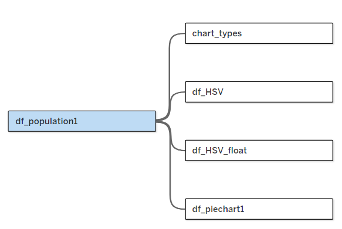